# R_Ex.1

Anastasia Koval

2024-11-10

```r
# install.packages('semTools')
library(lavaan)
library(semPlot)
library(semTools)
library(lavaanPlot)
```

# The task

Using data from the seminar (pirls_lesson.xlsx) check if there is a common construct “motivation” by taking the scales for internal (enjoy_r1 - enjoy_r6) and instrumental motivation (reason1 - reason6)

## Before you start checking, I’d like to say that I’m a free rider in this course (вольнослушатель), so it isn’t obligatory for you to check my works. If you don’t mind, I still want to do the tasks for practice but if it disturbs you, I will not send the tasks here (just do it for myself on my laptop). Please let me know, it it disturbs you.

```r
pirls <- rio::import("/Users/anastasiakoval/Downloads/Master programme/DatAn/DatAn Advanced/pirls_lesson.xlsx")
```

Let’s look at the variables

```r
summary(subset(pirls, select=c(enjoy_r1:enjoy_r6,reason1:reason6)))
```

```
##     enjoy_r1        enjoy_r2       enjoy_r3       enjoy_r4       enjoy_r5
##  Min.   :1.000   Min.   :1.00   Min.   :1.00   Min.   :1.00   Min.   :1.00
##  1st Qu.:1.000   1st Qu.:1.00   1st Qu.:1.00   1st Qu.:3.00   1st Qu.:1.00
##  Median :2.000   Median :2.00   Median :1.00   Median :4.00   Median :2.00
##  Mean   :2.289   Mean   :1.96   Mean   :1.67   Mean   :3.34   Mean   :1.99
##  3rd Qu.:3.000   3rd Qu.:3.00   3rd Qu.:2.00   3rd Qu.:4.00   3rd Qu.:3.00
##  Max.   :4.000   Max.   :4.00   Max.   :4.00   Max.   :4.00   Max.   :4.00
##  NA's   :30      NA's   :35     NA's   :45     NA's   :45     NA's   :39
##     enjoy_r6        reason1         reason2         reason3
##  Min.   :1.000   Min.   :1.000   Min.   :1.000   Min.   :1.000
##  1st Qu.:1.000   1st Qu.:1.000   1st Qu.:1.000   1st Qu.:1.000
##  Median :1.000   Median :2.000   Median :1.000   Median :1.000
##  Mean   :1.698   Mean   :1.721   Mean   :1.184   Mean   :1.332
##  3rd Qu.:2.000   3rd Qu.:2.000   3rd Qu.:1.000   3rd Qu.:2.000
##  Max.   :4.000   Max.   :4.000   Max.   :4.000   Max.   :4.000
##  NA's   :20      NA's   :30      NA's   :36      NA's   :40
##     reason4         reason5         reason6
##  Min.   :1.000   Min.   :1.000   Min.   :1.000
##  1st Qu.:1.000   1st Qu.:1.000   1st Qu.:1.000
##  Median :1.000   Median :1.000   Median :1.000
##  Mean   :1.212   Mean   :1.125   Mean   :1.275
##  3rd Qu.:1.000   3rd Qu.:1.000   3rd Qu.:1.000
##  Max.   :4.000   Max.   :4.000   Max.   :4.000
##  NA's   :40      NA's   :39      NA's   :36
```

```r
table(pirls$enjoy_r2)
```

```
##
##    1    2    3    4
## 1850 1360  712  480
```

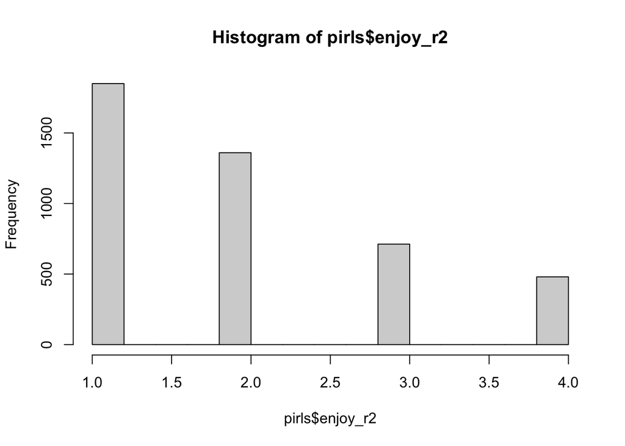

```r
hist(pirls$enjoy_r2)
```

```r
table(pirls$reason6)
```

```
##
##    1    2    3    4
## 3476  719  126   80
```

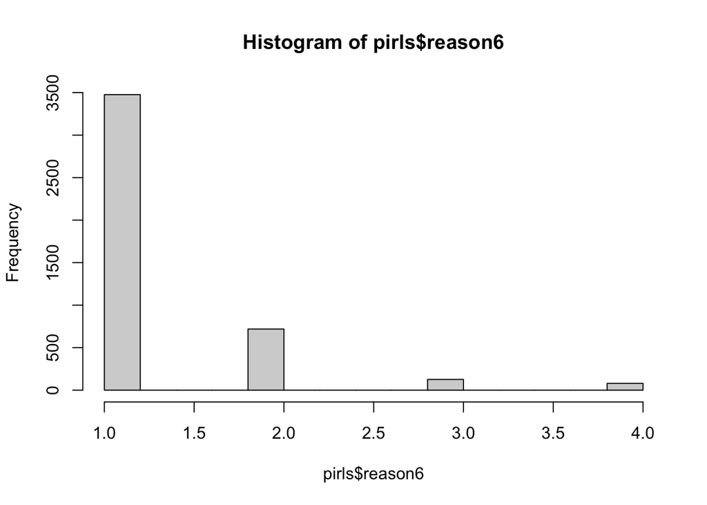

```r
hist(pirls$reason6)
```

# 1. Model estimation

```r
model_motivation <- "
internal_motivation =~ enjoy_r2 + enjoy_r1 + enjoy_r3 + enjoy_r4 + enjoy_r5 + enjoy_r6
instrumental_motivation     =~ reason1 + reason2 + reason3 + reason4 + reason5 + reason6"

# fit_motivation_1 <- cfa(model_motivation, pirls, std.lv = TRUE) # here ML is used

# summary(fit_motivation_1, std=T)

fit_motivation_1 <- cfa(model_motivation, data=pirls, std.lv=TRUE, estimator="DWLS", verbose=TRUE) # Here another estimator is used as the data did not have normal distribution
```

```
## lavoptions         ...
```

[output not shown]

```r
summary(fit_motivation_1, fit.measures= TRUE, standardized=TRUE)
```

```
## lavaan 0.6-19 ended normally after 26 iterations
##
##   Estimator                                       DWLS
##   Optimization method                           NLMINB
##   Number of model parameters                        25
##
##                                                   Used       Total
##   Number of observations                          4298        4437
##
## Model Test User Model:
##
##   Test statistic                               314.191
##   Degrees of freedom                                53
##   P-value (Chi-square)                           0.000
##
## Model Test Baseline Model:
##
##   Test statistic                             12388.819
##   Degrees of freedom                                66
##   P-value                                        0.000
##
## User Model versus Baseline Model:
##
##   Comparative Fit Index (CFI)                    0.979
##   Tucker-Lewis Index (TLI)                       0.974
##
## Root Mean Square Error of Approximation:
##
##   RMSEA                                          0.034
##   90 Percent confidence interval - lower         0.030
##   90 Percent confidence interval - upper         0.038
##   P-value H_0: RMSEA <= 0.050                    1.000
##   P-value H_0: RMSEA >= 0.080                    0.000
##
## Standardized Root Mean Square Residual:
##
##   SRMR                                           0.040
##
## Parameter Estimates:
##
```

[output cut: 42 more lines]

```
##                    Estimate  Std.Err  z-value  P(>|z|)   Std.lv  Std.all
##    .enjoy_r2          0.722    0.022   33.288    0.000    0.722    0.712
##    .enjoy_r1          1.266    0.017   76.714    0.000    1.266    0.938
##    .enjoy_r3          0.457    0.023   20.228    0.000    0.457    0.592
##    .enjoy_r4          0.507    0.025   20.199    0.000    0.507    0.590
##    .enjoy_r5          0.403    0.022   18.383    0.000    0.403    0.475
##    .enjoy_r6          0.273    0.024   11.502    0.000    0.273    0.372
##    .reason1           0.489    0.021   23.044    0.000    0.489    0.659
##    .reason2           0.181    0.013   14.273    0.000    0.181    0.815
##    .reason3           0.309    0.015   20.718    0.000    0.309    0.821
##    .reason4           0.173    0.014   12.532    0.000    0.173    0.675
##    .reason5           0.138    0.011   12.005    0.000    0.138    0.857
##    .reason6           0.255    0.017   14.779    0.000    0.255    0.718
##     internal_mtvtn    1.000                               1.000    1.000
##     instrmntl_mtvt    1.000                               1.000    1.000
```

If we look at these items in internal motivation, we can see that they are reversed as they have negative loadings:  
1) enjoy_r1 (I only read when I have to), std.all = . -0.249 2) enjoy_r4 (I think reading is boring), std.all = -0.640

Let’s recode them to ensure accurate measurement and interpetation:

```r
pirls$enjoy_r1r <- car::recode(pirls$enjoy_r1, '1=4;2=3;3=2;4=1')
pirls$enjoy_r4r <- car::recode(pirls$enjoy_r4, '1=4;2=3;3=2;4=1')

model_motivation <- "
internal_motivation =~ enjoy_r2 + enjoy_r1r + enjoy_r3 + enjoy_r4r + enjoy_r5 + enjoy_r6
instrumental_motivation     =~ reason1 + reason2 + reason3 + reason4 + reason5 + reason6"

fit_motivation_1 <- cfa(model_motivation, data=pirls, std.lv=TRUE, estimator="DWLS", verbose=TRUE) # Here another estimator is used as the data did not have normal distribution
```

```
## lavoptions         ...
```

[output not shown]

```r
summary(fit_motivation_1, std=T, fit=T)
```

```
## lavaan 0.6-19 ended normally after 26 iterations
##
##   Estimator                                       DWLS
##   Optimization method                           NLMINB
##   Number of model parameters                        25
##
##                                                   Used       Total
##   Number of observations                          4298        4437
##
## Model Test User Model:
##
##   Test statistic                               314.191
##   Degrees of freedom                                53
##   P-value (Chi-square)                           0.000
##
## Model Test Baseline Model:
##
##   Test statistic                             12388.819
##   Degrees of freedom                                66
##   P-value                                        0.000
##
## User Model versus Baseline Model:
##
##   Comparative Fit Index (CFI)                    0.979
##   Tucker-Lewis Index (TLI)                       0.974
##
## Root Mean Square Error of Approximation:
##
##   RMSEA                                          0.034
##   90 Percent confidence interval - lower         0.030
##   90 Percent confidence interval - upper         0.038
##   P-value H_0: RMSEA <= 0.050                    1.000
##   P-value H_0: RMSEA >= 0.080                    0.000
##
## Standardized Root Mean Square Residual:
##
##   SRMR                                           0.040
##
## Parameter Estimates:
##
```

[output cut: 42 more lines]

```
##                    Estimate  Std.Err  z-value  P(>|z|)   Std.lv  Std.all
##    .enjoy_r2          0.722    0.022   33.288    0.000    0.722    0.712
##    .enjoy_r1r         1.266    0.017   76.714    0.000    1.266    0.938
##    .enjoy_r3          0.457    0.023   20.228    0.000    0.457    0.592
##    .enjoy_r4r         0.507    0.025   20.199    0.000    0.507    0.590
##    .enjoy_r5          0.403    0.022   18.383    0.000    0.403    0.475
##    .enjoy_r6          0.273    0.024   11.502    0.000    0.273    0.372
##    .reason1           0.489    0.021   23.044    0.000    0.489    0.659
##    .reason2           0.181    0.013   14.273    0.000    0.181    0.815
##    .reason3           0.309    0.015   20.718    0.000    0.309    0.821
##    .reason4           0.173    0.014   12.532    0.000    0.173    0.675
##    .reason5           0.138    0.011   12.005    0.000    0.138    0.857
##    .reason6           0.255    0.017   14.779    0.000    0.255    0.718
##     internal_mtvtn    1.000                               1.000    1.000
##     instrmntl_mtvt    1.000                               1.000    1.000
```

We can see the correlation between internal and instrumental motivation in the Estimates: Covariances: Estimate Std.Err z-value P(>|z|) Std.lv Std.all internal_motivation ~~  
instrmntl_mtvt 0.719 0.015 47.533 0.000 0.719 0.719

But let’s check it additionally:

```r
correlation <- parameterEstimates(fit_motivation_1)[parameterEstimates(fit_motivation_1)$op == "~~" & parameterEstimates(fit_motivation_1)$lhs == "internal_motivation" & parameterEstimates(fit_motivation_1)$rhs == "instrumental_motivation", "est"]

correlation
```

```
## [1] 0.7189785
```

```r
# parameterEstimates(fit_motivation_1) another way to check it
```

As we can see, the correlation is 0.719.

# 2. Model testing

```r
fitmeasures(fit_motivation_1)
```

```
##                  npar                  fmin                 chisq
##                25.000                 0.037               314.191
##                    df                pvalue        baseline.chisq
##                53.000                 0.000             12388.819
##           baseline.df       baseline.pvalue                   cfi
##                66.000                 0.000                 0.979
##                   tli                  nnfi                   rfi
##                 0.974                 0.974                 0.968
##                   nfi                  pnfi                   ifi
##                 0.975                 0.783                 0.979
##                   rni                 rmsea        rmsea.ci.lower
##                 0.979                 0.034                 0.030
##        rmsea.ci.upper        rmsea.ci.level          rmsea.pvalue
##                 0.038                 0.900                 1.000
##        rmsea.close.h0 rmsea.notclose.pvalue     rmsea.notclose.h0
##                 0.050                 0.000                 0.080
##                   rmr            rmr_nomean                  srmr
##                 0.026                 0.026                 0.040
##          srmr_bentler   srmr_bentler_nomean                  crmr
##                 0.040                 0.040                 0.044
##           crmr_nomean            srmr_mplus     srmr_mplus_nomean
##                 0.044                 0.040                 0.040
##                 cn_05                 cn_01                   gfi
##               971.934              1092.968                 0.991
##                  agfi                  pgfi                   mfi
##                 0.987                 0.673                 0.970
##                  ecvi
##                 0.085
```

```r
fitmeasures(fit_motivation_1, c('CFI','TLI','RMSEA','SRMR'))
```

```
##   cfi   tli rmsea  srmr
## 0.979 0.974 0.034 0.040
```

We have received these indices:  
cfi tli rmsea srmr 0.979 0.974 0.034 0.040

We can see that the model is already quite good with CFI > 0.9, TLI > 0.9, RMSEA and SRMR are quite small.

As for 90% confidence interval of RMSEA, it is equal to 0.030-0.038.

Finally, t’s check chi_square of the original model.

```r
chi_square_original <- fitMeasures(fit_motivation_1)["chisq"]
chi_square_original
```

```
##    chisq
## 314.1913
```

#3. Model improvement

```r
modindices(fit_motivation_1, standardized = T, sort. = T)
```

```
##                         lhs op       rhs     mi    epc sepc.lv sepc.all
## 52                enjoy_r1r ~~ enjoy_r4r 76.226 -0.154  -0.154   -0.192
## 35  instrumental_motivation =~ enjoy_r1r 71.976  0.305   0.305    0.263
## 34  instrumental_motivation =~  enjoy_r2 63.147 -0.329  -0.329   -0.326
## 28      internal_motivation =~   reason1 31.444 -0.266  -0.266   -0.309
## 45                 enjoy_r2 ~~   reason1 26.066 -0.086  -0.086   -0.144
## 55                enjoy_r1r ~~   reason1 25.399  0.084   0.084    0.106
## 98                  reason2 ~~   reason5 25.088 -0.034  -0.034   -0.212
## 59                enjoy_r1r ~~   reason5 21.933  0.034   0.034    0.082
## 56                enjoy_r1r ~~   reason2 18.651  0.037   0.037    0.077
## 54                enjoy_r1r ~~  enjoy_r6 18.154 -0.073  -0.073   -0.124
## 44                 enjoy_r2 ~~  enjoy_r6 18.008  0.083   0.083    0.187
## 42                 enjoy_r2 ~~ enjoy_r4r 15.494  0.076   0.076    0.126
## 29      internal_motivation =~   reason2 14.847  0.090   0.090    0.191
## 32      internal_motivation =~   reason5 13.706  0.074   0.074    0.185
```

[output cut: 143 more lines]

```r
# Modify the model based on modification indices
# Add:
# 1) instrumental_motivation    =~  enjoy_r1r (I only read when I have to), this is the biggest crossloading

model_motivation_2 <- "
internal_motivation =~ enjoy_r2 + enjoy_r1r + enjoy_r3 + enjoy_r4r + enjoy_r5 + enjoy_r6
instrumental_motivation     =~ reason1 + reason2 + reason3 + reason4 + reason5 + reason6
instrumental_motivation =~  enjoy_r1r
"

fit_motivation_2 <- cfa(model_motivation_2, data=pirls, std.lv=TRUE, estimator="DWLS", verbose=TRUE)
```

```
## lavoptions         ...
```

[output not shown]

[output cut: 11 more lines]

[output not shown]

```r
summary(fit_motivation_2, std=T, fit=T)
```

```
## lavaan 0.6-19 ended normally after 31 iterations
##
##   Estimator                                       DWLS
##   Optimization method                           NLMINB
##   Number of model parameters                        26
##
##                                                   Used       Total
##   Number of observations                          4298        4437
##
## Model Test User Model:
##
##   Test statistic                               242.046
##   Degrees of freedom                                52
##   P-value (Chi-square)                           0.000
##
## Model Test Baseline Model:
##
##   Test statistic                             12388.819
##   Degrees of freedom                                66
##   P-value                                        0.000
##
## User Model versus Baseline Model:
##
##   Comparative Fit Index (CFI)                    0.985
##   Tucker-Lewis Index (TLI)                       0.980
##
## Root Mean Square Error of Approximation:
##
##   RMSEA                                          0.029
##   90 Percent confidence interval - lower         0.026
##   90 Percent confidence interval - upper         0.033
##   P-value H_0: RMSEA <= 0.050                    1.000
##   P-value H_0: RMSEA >= 0.080                    0.000
##
## Standardized Root Mean Square Residual:
##
##   SRMR                                           0.038
##
## Parameter Estimates:
##
```

[output cut: 44 more lines]

```
##                    Estimate  Std.Err  z-value  P(>|z|)   Std.lv  Std.all
##    .enjoy_r2          0.725    0.022   33.558    0.000    0.725    0.716
##    .enjoy_r1r         1.184    0.024   49.484    0.000    1.184    0.877
##    .enjoy_r3          0.465    0.022   20.690    0.000    0.465    0.601
##    .enjoy_r4r         0.511    0.025   20.451    0.000    0.511    0.595
##    .enjoy_r5          0.412    0.022   19.026    0.000    0.412    0.487
##    .enjoy_r6          0.283    0.024   11.996    0.000    0.283    0.385
##    .reason1           0.488    0.021   23.048    0.000    0.488    0.659
##    .reason2           0.181    0.013   14.237    0.000    0.181    0.813
##    .reason3           0.310    0.015   20.773    0.000    0.310    0.823
##    .reason4           0.173    0.014   12.522    0.000    0.173    0.675
##    .reason5           0.137    0.011   11.964    0.000    0.137    0.854
##    .reason6           0.256    0.017   14.849    0.000    0.256    0.720
##     internal_mtvtn    1.000                               1.000    1.000
##     instrmntl_mtvt    1.000                               1.000    1.000
```

```r
fitmeasures(fit_motivation_2, c('CFI','TLI','rmsea','srmr'))
```

```
##   cfi   tli rmsea  srmr
## 0.985 0.980 0.029 0.038
```

We can see that the model is even better: Old version. cfi tli rmsea srmr 0.979 0.974 0.034 0.040

New version: cfi tli rmsea srmr 0.985 0.980 0.029 0.038

Now let’s check chi_square:

```r
chi_square_second <- fitMeasures(fit_motivation_2)["chisq"]
chi_square_second
```

```
##    chisq
## 242.0458
```

```r
chi_square_difference = chi_square_original - chi_square_second
chi_square_difference
```

```
##    chisq
## 72.14552
```

```r
modindices(fit_motivation_2, standardized = T, sort. = T)
```

```
##                         lhs op       rhs     mi    epc sepc.lv sepc.all
## 35  instrumental_motivation =~  enjoy_r2 48.769 -0.286  -0.286   -0.284
## 52                enjoy_r1r ~~ enjoy_r4r 48.622 -0.127  -0.127   -0.164
## 37  instrumental_motivation =~ enjoy_r4r 25.313  0.205   0.205    0.221
## 51                enjoy_r1r ~~  enjoy_r3 24.961  0.088   0.088    0.118
## 98                  reason2 ~~   reason5 24.385 -0.033  -0.033   -0.210
## 45                 enjoy_r2 ~~   reason1 22.328 -0.080  -0.080   -0.134
## 33      internal_motivation =~   reason5 17.312  0.077   0.077    0.193
## 30      internal_motivation =~   reason2 15.977  0.087   0.087    0.185
## 29      internal_motivation =~   reason1 15.251 -0.173  -0.173   -0.201
## 44                 enjoy_r2 ~~  enjoy_r6 14.238  0.073   0.073    0.162
## 42                 enjoy_r2 ~~ enjoy_r4r 13.405  0.070   0.070    0.116
## 47                 enjoy_r2 ~~   reason3 11.765 -0.040  -0.040   -0.084
## 103                 reason4 ~~   reason5  9.743 -0.025  -0.025   -0.161
## 50                 enjoy_r2 ~~   reason6  9.259 -0.038  -0.038   -0.089
```

[output cut: 141 more lines]

```r
# Modify the model based on modification indices
# Add:
# 2) instrumental_motivation    =~  enjoy_r2 (I like to talk to other people about books), this is the next change

model_motivation_3 <- "
internal_motivation =~ enjoy_r2 + enjoy_r1r + enjoy_r3 + enjoy_r4r + enjoy_r5 + enjoy_r6
instrumental_motivation     =~ reason1 + reason2 + reason3 + reason4 + reason5 + reason6
instrumental_motivation =~  enjoy_r1r
instrumental_motivation =~  enjoy_r2
"

fit_motivation_3 <- cfa(model_motivation_3, data=pirls, std.lv=TRUE, estimator="DWLS", verbose=TRUE)
```

```
## lavoptions         ...
```

[output not shown]

[output cut: 9 more lines]

[output not shown]

```r
summary(fit_motivation_3, std=T, fit=T)
```

```
## lavaan 0.6-19 ended normally after 33 iterations
##
##   Estimator                                       DWLS
##   Optimization method                           NLMINB
##   Number of model parameters                        27
##
##                                                   Used       Total
##   Number of observations                          4298        4437
##
## Model Test User Model:
##
##   Test statistic                               192.081
##   Degrees of freedom                                51
##   P-value (Chi-square)                           0.000
##
## Model Test Baseline Model:
##
##   Test statistic                             12388.819
##   Degrees of freedom                                66
##   P-value                                        0.000
##
## User Model versus Baseline Model:
##
##   Comparative Fit Index (CFI)                    0.989
##   Tucker-Lewis Index (TLI)                       0.985
##
## Root Mean Square Error of Approximation:
##
##   RMSEA                                          0.025
##   90 Percent confidence interval - lower         0.022
##   90 Percent confidence interval - upper         0.029
##   P-value H_0: RMSEA <= 0.050                    1.000
##   P-value H_0: RMSEA >= 0.080                    0.000
##
## Standardized Root Mean Square Residual:
##
##   SRMR                                           0.035
##
## Parameter Estimates:
##
```

[output cut: 46 more lines]

```
##                    Estimate  Std.Err  z-value  P(>|z|)   Std.lv  Std.all
##    .enjoy_r2          0.733    0.021   34.150    0.000    0.733    0.723
##    .enjoy_r1r         1.194    0.023   53.063    0.000    1.194    0.885
##    .enjoy_r3          0.458    0.023   20.200    0.000    0.458    0.592
##    .enjoy_r4r         0.498    0.025   19.700    0.000    0.498    0.580
##    .enjoy_r5          0.399    0.022   18.034    0.000    0.399    0.471
##    .enjoy_r6          0.267    0.024   11.097    0.000    0.267    0.363
##    .reason1           0.487    0.021   22.975    0.000    0.487    0.657
##    .reason2           0.181    0.013   14.242    0.000    0.181    0.813
##    .reason3           0.309    0.015   20.731    0.000    0.309    0.821
##    .reason4           0.173    0.014   12.530    0.000    0.173    0.675
##    .reason5           0.137    0.011   11.968    0.000    0.137    0.854
##    .reason6           0.256    0.017   14.838    0.000    0.256    0.720
##     internal_mtvtn    1.000                               1.000    1.000
##     instrmntl_mtvt    1.000                               1.000    1.000
```

```r
fitmeasures(fit_motivation_3, c('CFI','TLI','rmsea','srmr'))
```

```
##   cfi   tli rmsea  srmr
## 0.989 0.985 0.025 0.035
```

The model is even better.

Old version: cfi tli rmsea srmr 0.985 0.980 0.029 0.038 New version: cfi tli rmsea srmr 0.989 0.985 0.025 0.035

# 4. The plot

```r
# option 1
lavaanPlot(model = fit_motivation_3, graph_options = list(rankdir = "LR"), coefs = TRUE, covs = TRUE, stand = TRUE)
```

[interactive chart not shown]

```r
# option 2
lavaanPlot(model = fit_motivation_3, node_options = list(shape = "box", fontname = "Helvetica"),
           edge_options = list(color = "grey"), coefs = TRUE, stand = FALSE, sig = 1.00, covs =TRUE)
```

[interactive chart not shown]